# Rate limiting steps of mRNA localization

Jonathan Harrison

22/09/2017

Outline of Figures:

Fig1: Drosophila egg chambers exhibit a characteristic network structure of connections between nurse cells A) Cartoon of tissue, B) Equivalent image of tissue, C) Diagram of connections between NCs via RCs.

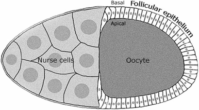

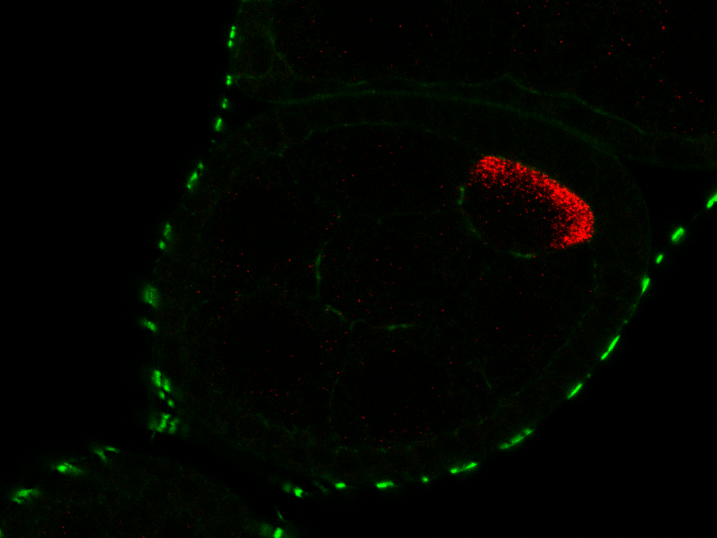

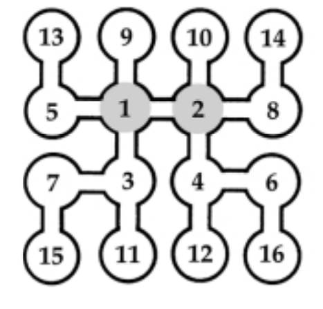

Fig2: Behaviour of differential equation model. A) Dynamics in time shown for each cell, B) Model related to network structure of nurse cells.

```
##
##  Elapsed Time: 0 seconds (Warm-up)
##                0.014303 seconds (Sampling)
##                0.014303 seconds (Total)
```

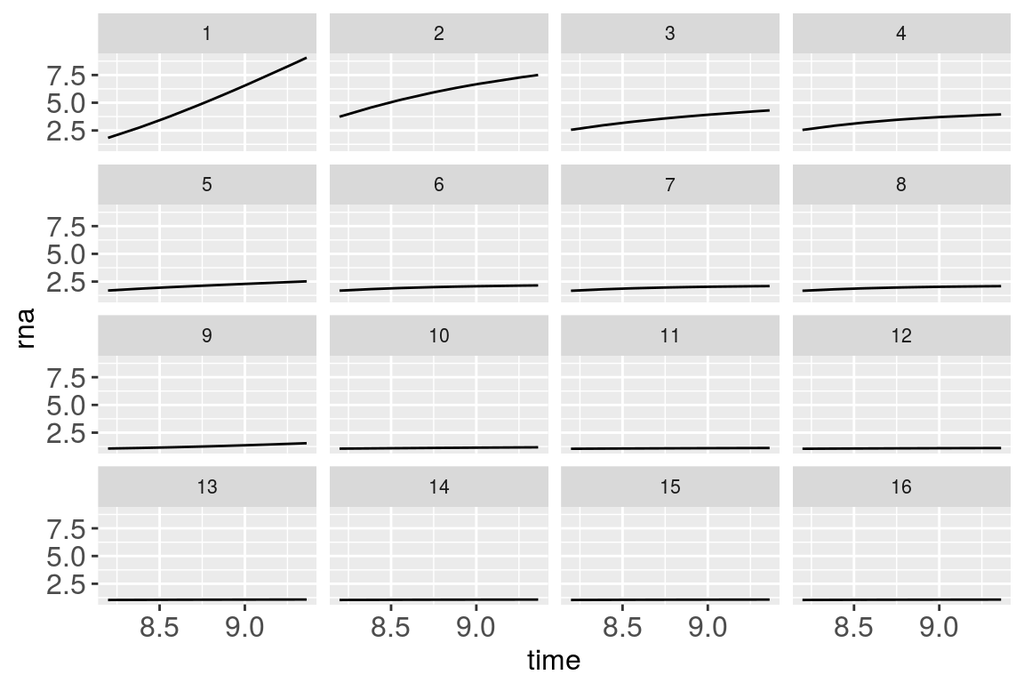

[figure not shown]

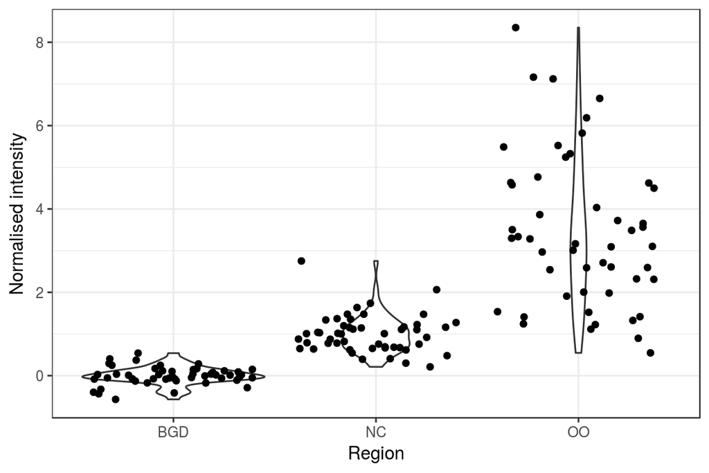

Fig4: Characterisation of the bias in directionality of transport through ring canals A) Schematic of transport between two compartments, B) Posterior pairs plot, C) Posterior predictive plot.

[figure not shown]

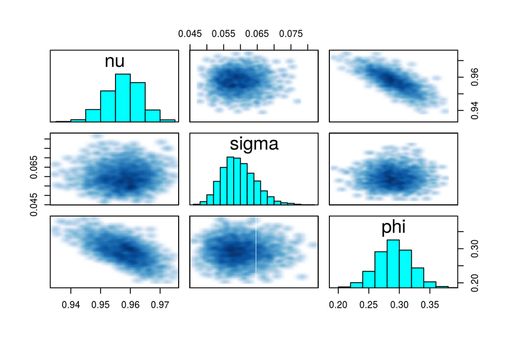

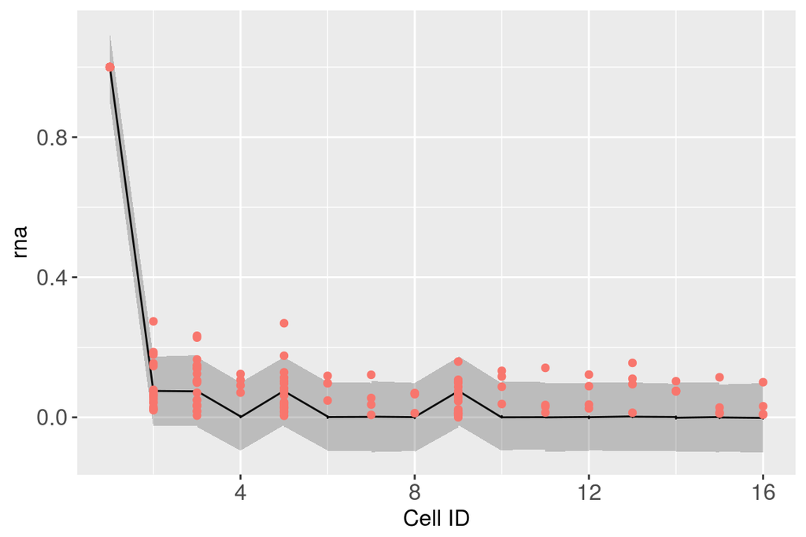

Fig5: Results of inference for dynamic model A) Posterior pairs plot, B) Posterior predictive distribution, C) Sensitivity to a, b.

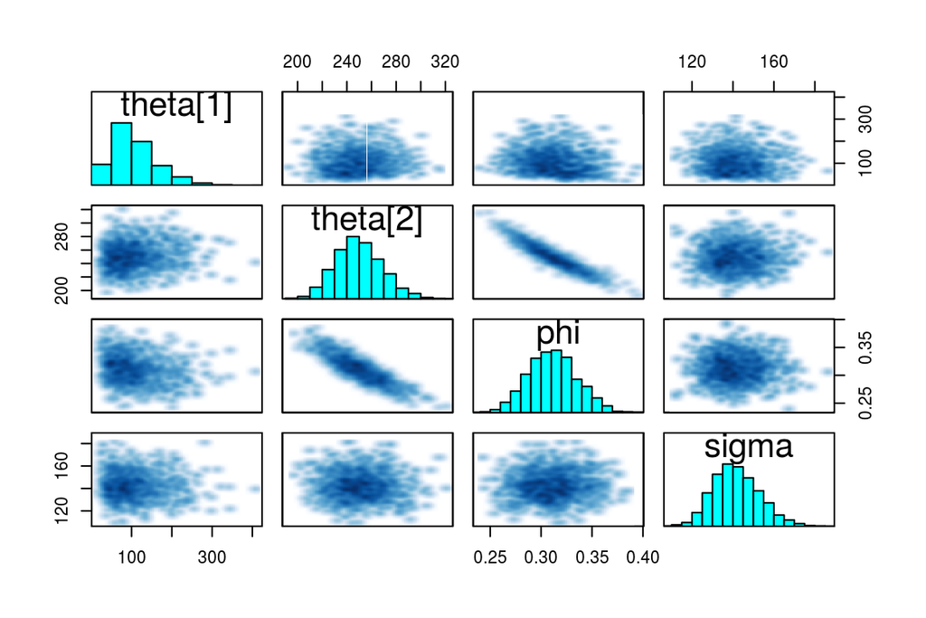

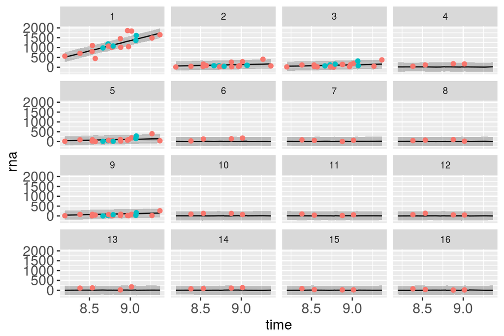

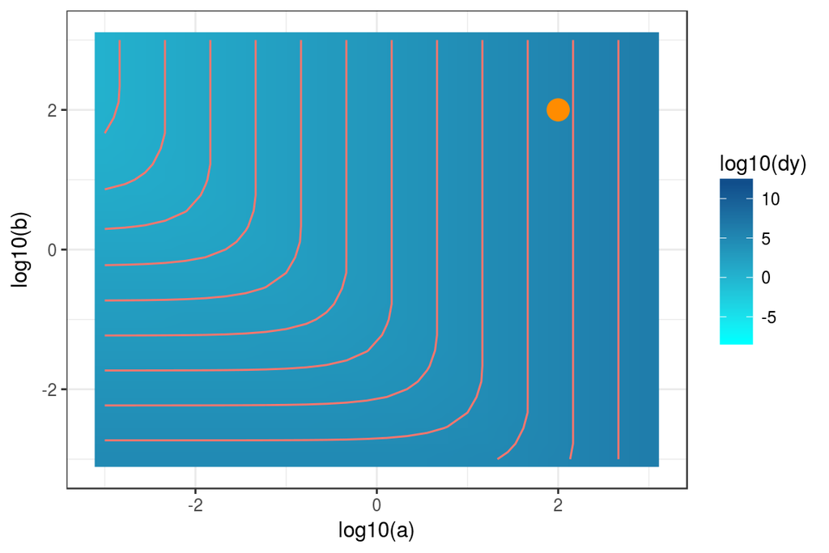

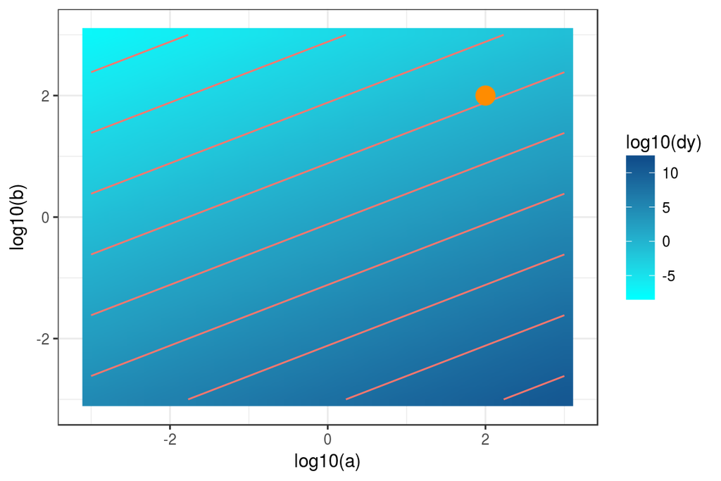